# David Puerta Lotero

### 2. Diseño de Filtros con Respuesta Infinita al Impulso (IIR)

Un filtro IIR es un tipo de filtro digital en el cual si su entrada es un impulso, la salida sera un numero ilimitado de terminos no nulos, es decir, nunca volvera a un estado de reposo. Para obtener la salida se emplean valores de la entrada actual y anteriores, ademas se toman valores anteriores de la salida que son almacenados en memoria y realimentados a la entrada.

Cree una senal y aplique por medio de filtros IIR un filtro pasa bajas, pasa altas , rechaza bandas , pasa bandas.

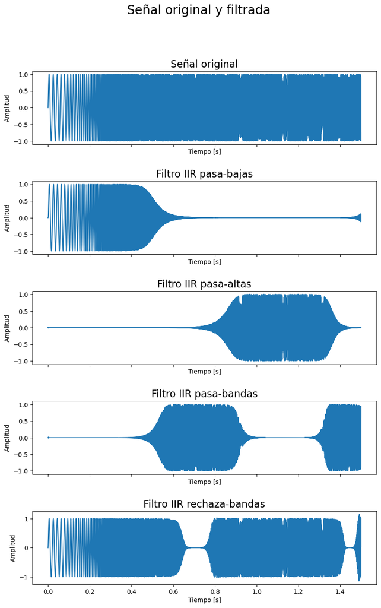

```python
import numpy as np
import matplotlib.pyplot as plt
from scipy.io.wavfile import write
from scipy.io.wavfile import read # libreria para lectura de archivos de audio
from IPython.display import Audio
import scipy.signal as sp

fs = 5000  # Frecuencia de muestreo
t_start = 0  # Tiempo inicial
t_end = 1.5  # Tiempo final
f_start = 50  # Frecuencia inicial
f_end = 1000  # Frecuencia final
t = np.arange(t_start, t_end, 1 / fs)
f_inst = f_start + ((f_end - f_start) / t_end) * (t ** 2)
# Generación de señal sinusoidal
signal = np.sin(2 * np.pi * f_inst * t)

# Diseñar filtro IIR pasa-bajas
fc_pb = 500  # Frecuencia de corte del filtro pasa-bajas
Wn_pb = fc_pb / (fs / 2)
b_pb, a_pb = sp.butter(6, Wn_pb, btype='low', analog=False, output='ba', fs=None)
y_pb = sp.lfilter(b_pb, a_pb, signal)

# Diseñar filtro IIR pasa-altas
fc_pa = 1500  # Frecuencia de corte del filtro pasa-altas
Wn_pa = fc_pa / (fs / 2)
b_pa, a_pa = sp.butter(6, Wn_pa, btype='high', analog=False, output='ba', fs=None)
y_pa = sp.lfilter(b_pa, a_pa, signal)

# Diseñar filtro IIR pasa-bandas
fc_pb1 = 600  # Frecuencia de corte inferior del filtro pasa-bandas
fc_pb2 = 1600  # Frecuencia de corte superior del filtro pasa-bandas
Wn_pb1 = fc_pb1 / (fs / 2)
Wn_pb2 = fc_pb2 / (fs / 2)
b_pbands, a_pbands = sp.butter(6, [Wn_pb1, Wn_pb2], btype='bandpass', analog=False, output='ba', fs=None)
y_pbands = sp.lfilter(b_pbands, a_pbands, signal)

# Diseñar filtro IIR rechaza-bandas
fc_rb1 = 800  # Frecuencia de corte inferior del filtro rechaza-bandas
fc_rb2 = 1200  # Frecuencia de corte superior del filtro rechaza-bandas
Wn_rb1 = fc_rb1 / (fs / 2)
Wn_rb2 = fc_rb2 / (fs / 2)
b_rb, a_rb = sp.butter(6, [Wn_rb1, Wn_rb2], btype='bandstop', analog=False, output='ba', fs=None)
y_rb = sp.lfilter(b_rb, a_rb, signal)

# Graficar señal original y filtrada
fig, axs = plt.subplots(5, 1, figsize=(10, 15), sharex=True)
fig.suptitle('Señal original y filtrada', fontsize=20)
plt.subplots_adjust(hspace=0.5)
axs[0].plot(t, signal)
axs[0].set_title('Señal original', fontsize=16)
axs[0].set_xlabel('Tiempo [s]')
axs[0].set_ylabel('Amplitud')

axs[1].plot(t, y_pb)
axs[1].set_title('Filtro IIR pasa-bajas', fontsize=16)
axs[1].set_xlabel('Tiempo [s]')
axs[1].set_ylabel('Amplitud')

axs[2].plot(t, y_pa)
axs[2].set_title('Filtro IIR pasa-altas', fontsize=16)
axs[2].set_xlabel('Tiempo [s]')
axs[2].set_ylabel('Amplitud')

axs[3].plot(t, y_pbands)
axs[3].set_title('Filtro IIR pasa-bandas', fontsize=16)
axs[3].set_xlabel('Tiempo [s]')
axs[3].set_ylabel('Amplitud')

axs[4].plot(t, y_rb)
axs[4].set_title('Filtro IIR rechaza-bandas', fontsize=16)
axs[4].set_xlabel('Tiempo [s]')
axs[4].set_ylabel('Amplitud')

plt.show()
```